# StockResearch

Gabriel Foix

2020-09-20

Find the best stock to buy

### Factor 1: Quality

1. Healthy debts: A company shoud generate cash in order to repay its debt. The **Free Cash Flow to Debt** ratio is a good indicator of how quick a company pays back its debt. The lower this ratio the better.

FCF2D = $\frac{Debt}{Free Cash Flow}$

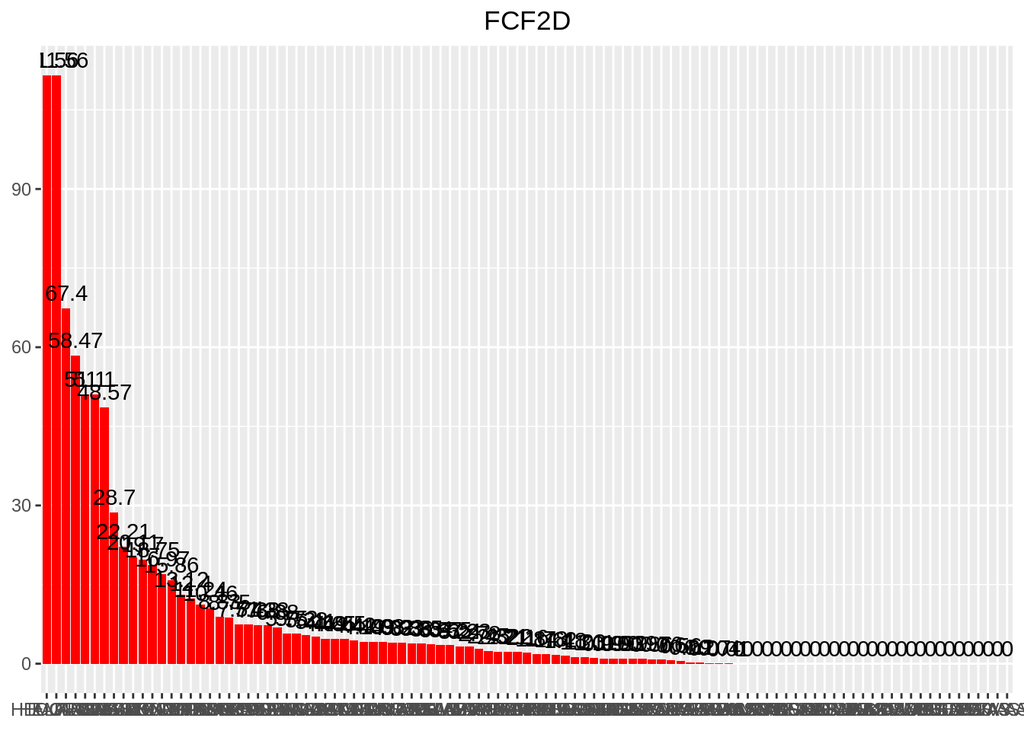

2. Profitability: ROA

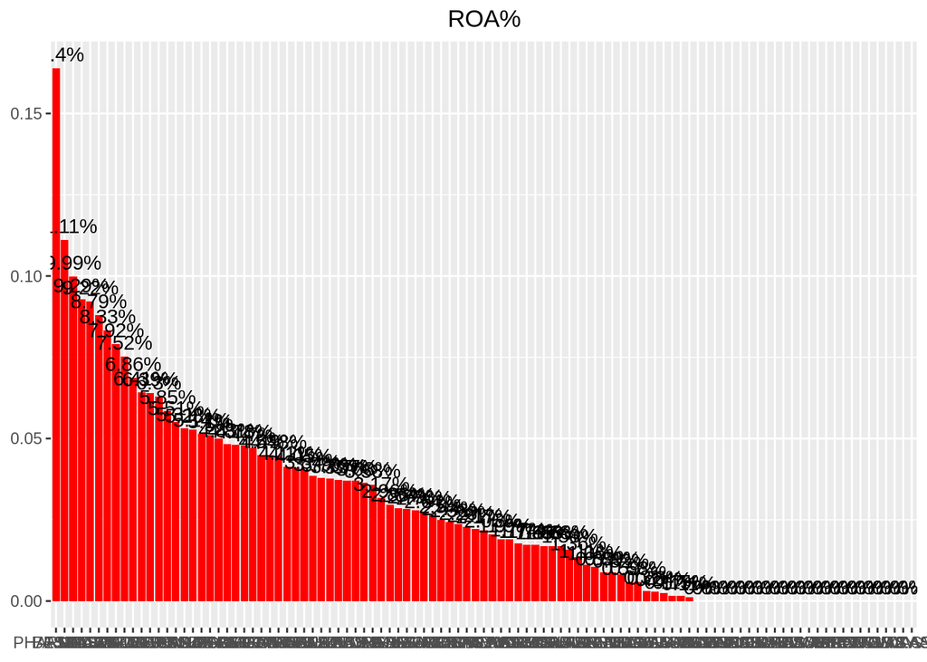

3. High Margin: We look for companies that generate free cash flow compare to its price. The **Free Cash Flow to Entreprise Value** ratio tells us how many years of cash flow would be needed to the return the 100% of the investment. Again, the lower, the better. Values bellow 1 would mean "free lunch".

FCF2EV = $\frac{EV}{Free Cash Flow}$

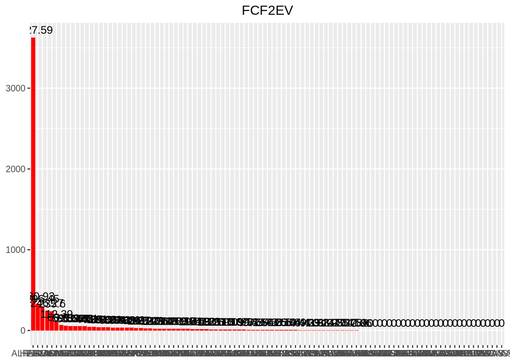

### Factor 2: Momentum

Don't hold onto a stock simply because it is high quality. So called quality stocks have cycles too. Stan Weinstein (page 177)

Generic Intermediate-Term Momentum Based on Gray-Vogel (page 80)

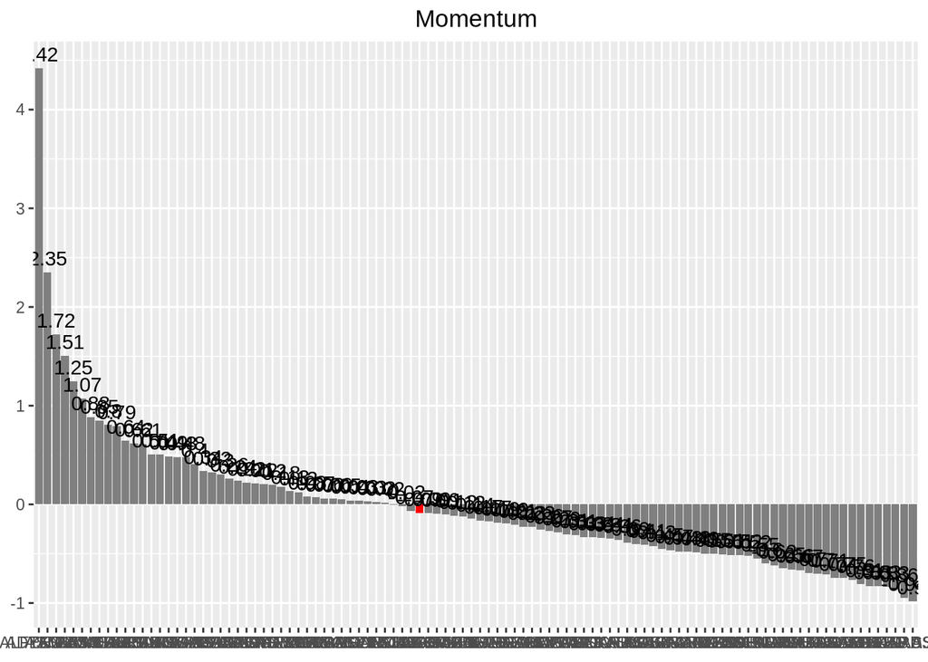

### Factor 3: Timing Signal

Sell Signal - Pr < 1% SMA 30 weeks and slope negative (< 0.1) Hold Signal - No Sell

### Summary

Summary

| Ticker | Signal | Quality | Momentum | Final_rank |
| --- | --- | --- | --- | --- |
| FLOW.AS | HOLD | 100.0 | 95 | 101.0 |
| ASM.AS | HOLD | 88.5 | 99 | 100.0 |
| ORDI.AS | HOLD | 91.0 | 91 | 99.0 |
| GLPG.AS | SELL | 99.0 | 81 | 98.0 |
| AXS.AS | HOLD | 98.0 | 77 | 97.0 |
| NEDAP.AS | HOLD | 88.5 | 83 | 96.0 |
| ASRNL.AS | HOLD | 96.0 | 66 | 94.5 |
| EAS2P.AS | SELL | 72.0 | 90 | 94.5 |
| CMCOM.AS | HOLD | 72.0 | 86 | 93.0 |
| ADYEN.AS | HOLD | 55.0 | 100 | 92.0 |
| NIBC.AS | HOLD | 94.0 | 60 | 91.0 |
| BFIT.AS | HOLD | 72.0 | 79 | 90.0 |
| VLK.AS | HOLD | 92.0 | 58 | 89.0 |
| MORE.AS | SELL | 72.0 | 74 | 88.0 |
| WKL.AS | HOLD | 50.5 | 94 | 87.0 |
| REN.AS | HOLD | 72.0 | 71 | 86.0 |
| HAL.AS | SELL | 97.0 | 45 | 85.0 |
| AD.AS | HOLD | 49.0 | 92 | 84.0 |
| BESI.AS | HOLD | 50.5 | 89 | 83.0 |
| KVW.AS | HOLD | 72.0 | 64 | 82.0 |
| PNL.AS | HOLD | 82.0 | 51 | 81.0 |
| ASML.AS | HOLD | 34.0 | 97 | 79.5 |
| PHARM.AS | SELL | 44.0 | 87 | 79.5 |
| HDG.AS | HOLD | 85.5 | 42 | 78.0 |
| DPA.AS | HOLD | 84.0 | 41 | 77.0 |
| CTAC.AS | HOLD | 85.5 | 38 | 76.0 |
| AGN.AS | SELL | 90.0 | 33 | 74.5 |
| UNA.AS | HOLD | 54.0 | 69 | 74.5 |
| INGA.AS | HOLD | 93.0 | 29 | 72.5 |
| BGHL.AS | HOLD | 72.0 | 50 | 72.5 |

[output cut: 71 more lines]